# UBER TRANSPORTATION INSIGHTS AND ANALYSIS

```python
import pandas as pd
```

```python
df=pd.read_csv(r"UberDataset.csv")
```

## Cost Allocation: What percentage of total miles traveled are attributed to business vs. personal trips, and how does this impact expense reporting?

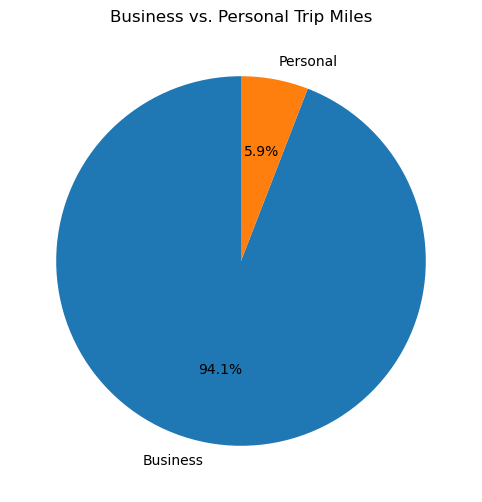

```python
# Import libraries
import pandas as pd
import matplotlib.pyplot as plt

# Load dataset (assuming df is your DataFrame)
# df = pd.read_csv("UberDataset[1].csv")

# 1. Cost Allocation Analysis
category_miles = df.groupby('CATEGORY')['MILES'].sum().reset_index()

# Plot
plt.figure(figsize=(8, 6))
plt.pie(category_miles['MILES'],
        labels=category_miles['CATEGORY'],
        autopct='%1.1f%%',
        startangle=90)
plt.title('Business vs. Personal Trip Miles')
plt.savefig("Business vs. Personal Trip Miles.png")
plt.show()
```

## High-Cost Routes: Which routes (start-to-stop) have the highest mileage for business purposes, and what is their frequency?

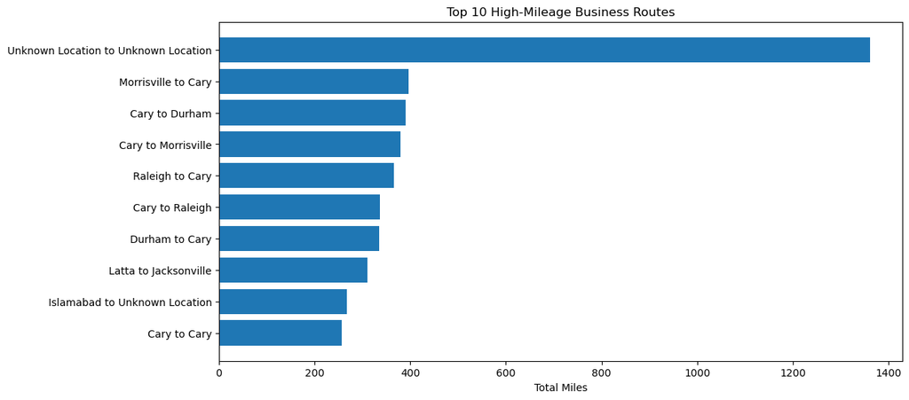

```python
# Group by route and sort
route_miles = df.groupby(['START', 'STOP'])['MILES'].sum().reset_index()
top_routes = route_miles.sort_values('MILES', ascending=False).head(10)

# Plot
plt.figure(figsize=(12, 6))
plt.barh(top_routes['START'] + ' to ' + top_routes['STOP'], top_routes['MILES'])
plt.title('Top 10 High-Mileage Business Routes')
plt.xlabel('Total Miles')
plt.gca().invert_yaxis()
plt.savefig("Top 10 High-Mileage Business Routes.png")
plt.show()
```

## Purpose Efficiency: Which trip purposes (e.g., "Customer Visit," "Meeting") account for the highest mileage, and are these trips yielding measurable business outcomes?

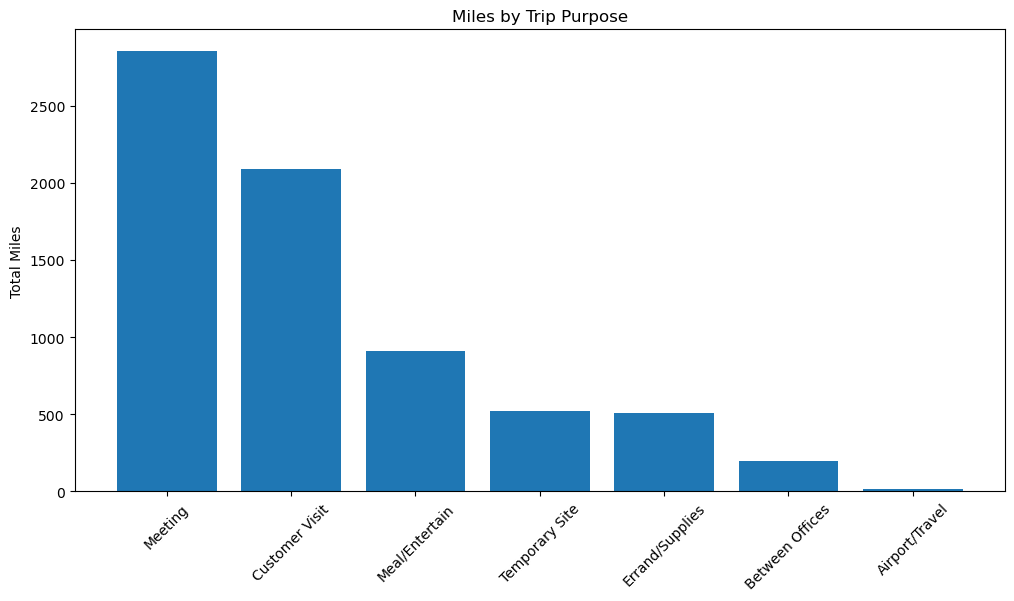

```python
purpose_miles = df[df['CATEGORY'] == 'Business'].groupby('PURPOSE')['MILES'].sum().reset_index()
purpose_miles = purpose_miles.sort_values('MILES', ascending=False)

# Plot
plt.figure(figsize=(12, 6))
plt.bar(purpose_miles['PURPOSE'], purpose_miles['MILES'])
plt.title('Miles by Trip Purpose')
plt.xticks(rotation=45)
plt.ylabel('Total Miles')
plt.savefig("Miles by Trip Purpose.png")
plt.show()
```

## Short vs. Long Trips: What is the average mileage for business trips, and do short trips (e.g., errands) outweigh long-distance trips in frequency or cost?

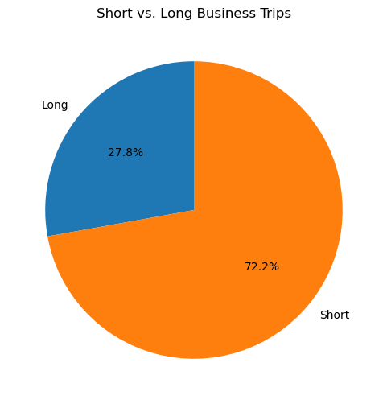

```python
import numpy as np  # Add this import at the top of your code

# 5. Short vs. Long Trips
df['TRIP_TYPE'] = np.where(df['MILES'] < 10, 'Short', 'Long')
trip_type = df[df['CATEGORY'] == 'Business'].groupby('TRIP_TYPE').size()

# Plot
plt.figure(figsize=(6, 6))
plt.pie(trip_type, labels=trip_type.index, autopct='%1.1f%%', startangle=90)
plt.title('Short vs. Long Business Trips')
plt.savefig("Short vs. Long Business Trips.png")
plt.show()
```

## Common Destinations: Which locations (e.g., "Cary," "Raleigh," "Morrisville") are most frequented for business purposes, and could recurring trips be optimized?

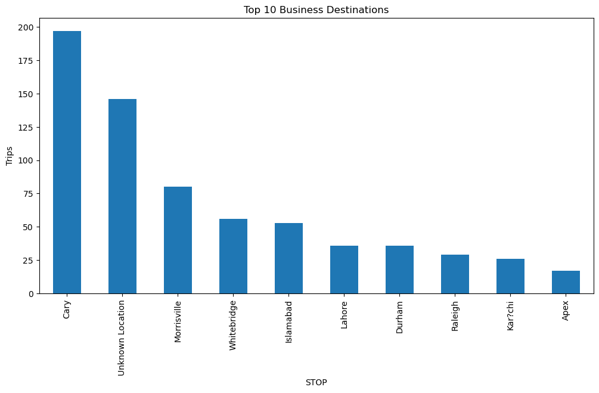

```python
top_destinations = df[df['CATEGORY'] == 'Business']['STOP'].value_counts().head(10)

# Plot
plt.figure(figsize=(12, 6))
top_destinations.plot(kind='bar')
plt.title('Top 10 Business Destinations')
plt.ylabel('Trips')
plt.savefig("Top 10 Business Destinations.png")
plt.show()
```

## Intercity Travel: How often do employees travel between cities (e.g., Cary to Raleigh), and is there potential to consolidate trips or use alternative transportation?

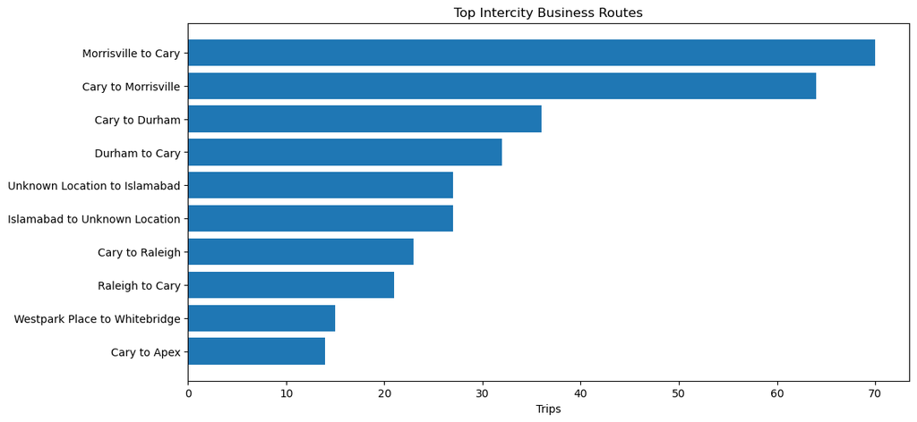

```python
intercity = df[(df['CATEGORY'] == 'Business') & (df['START'] != df['STOP'])]
intercity_count = intercity.groupby(['START', 'STOP']).size().reset_index(name='TRIPS')
intercity_top = intercity_count.sort_values('TRIPS', ascending=False).head(10)

# Plot
plt.figure(figsize=(12, 6))
plt.barh(intercity_top['START'] + ' to ' + intercity_top['STOP'], intercity_top['TRIPS'])
plt.title('Top Intercity Business Routes')
plt.xlabel('Trips')
plt.gca().invert_yaxis()
plt.savefig("Top Intercity Business Routes.png")
plt.show()
```

## Temporary Site Impact: What is the mileage and frequency of trips labeled "Temporary Site," and do these locations warrant permanent infrastructure?

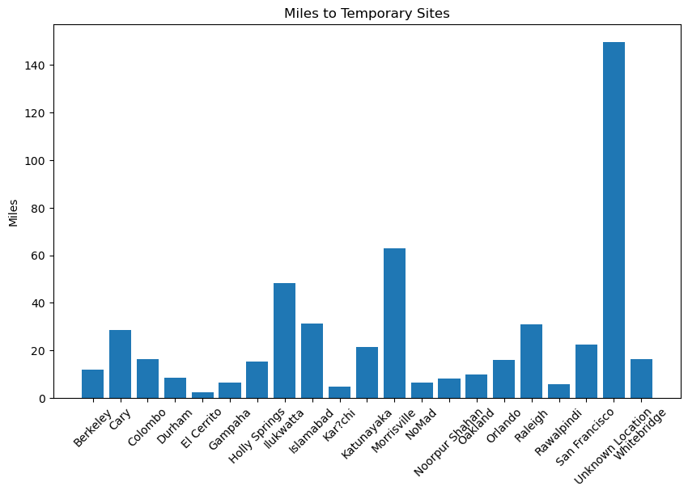

```python
temp_sites = df[df['PURPOSE'] == 'Temporary Site']
temp_miles = temp_sites.groupby('STOP')['MILES'].sum().reset_index()

# Plot
plt.figure(figsize=(10, 6))
plt.bar(temp_miles['STOP'], temp_miles['MILES'])
plt.title('Miles to Temporary Sites')
plt.xticks(rotation=45)
plt.ylabel('Miles')
plt.savefig("Miles to Temporary Sites.png")
plt.show()
```

## Errand Efficiency: Are "Errand/Supplies" trips clustered in specific areas, and could local partnerships or centralized procurement reduce travel?

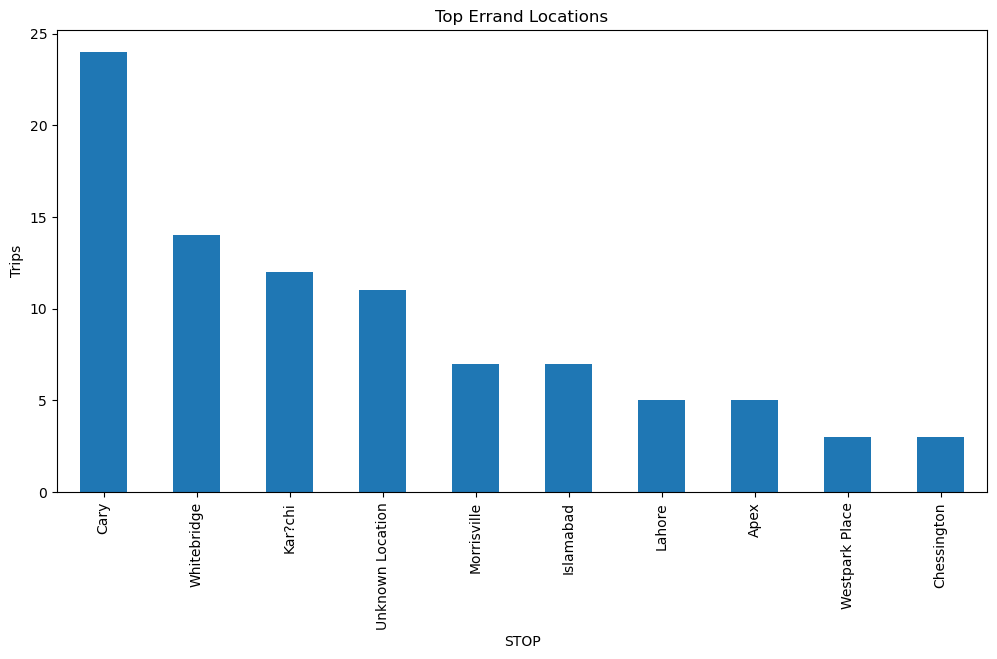

```python
errands = df[df['PURPOSE'] == 'Errand/Supplies']
errand_locations = errands['STOP'].value_counts().head(10)

# Plot
plt.figure(figsize=(12, 6))
errand_locations.plot(kind='bar')
plt.title('Top Errand Locations')
plt.ylabel('Trips')
plt.savefig("Top Errand Locations.png")
plt.show()
```

## Personal Use Flagging: How many trips marked as "Business" lack a defined purpose, and could some be misclassified personal trips?

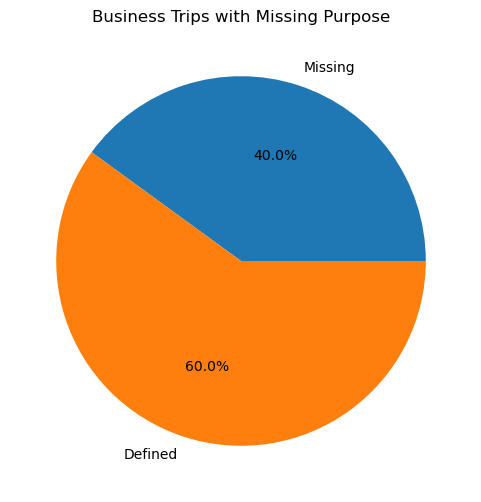

```python
missing_purpose = df[(df['CATEGORY'] == 'Business') & (df['PURPOSE'].isna())]
missing_count = len(missing_purpose)
total_business = len(df[df['CATEGORY'] == 'Business'])
percent_missing = (missing_count / total_business) * 100

# Plot
plt.figure(figsize=(6, 6))
plt.pie([missing_count, total_business - missing_count], labels=['Missing', 'Defined'], autopct='%1.1f%%')
plt.title('Business Trips with Missing Purpose')
plt.savefig("Business Trips with Missing Purpose.png")
plt.show()
```

## International Travel: What is the frequency and cost of trips to international locations (e.g., "Islamabad," "Colombo"), and are these aligned with organizational goals?

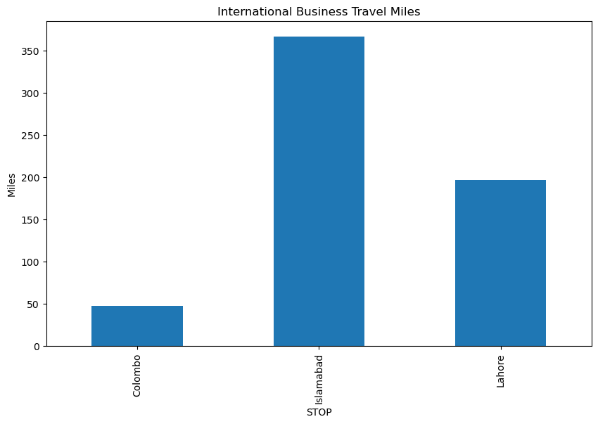

```python
international = df[df['STOP'].isin(['Islamabad', 'Colombo', 'Lahore'])]
intl_miles = international.groupby('STOP')['MILES'].sum()

# Plot
plt.figure(figsize=(10, 6))
intl_miles.plot(kind='bar')
plt.title('International Business Travel Miles')
plt.ylabel('Miles')
plt.savefig("International Business Travel Miles.png")
plt.show()
```

## ROI of Travel: For high-mileage categories like "Customer Visit," can we correlate travel frequency with client retention or revenue growth?

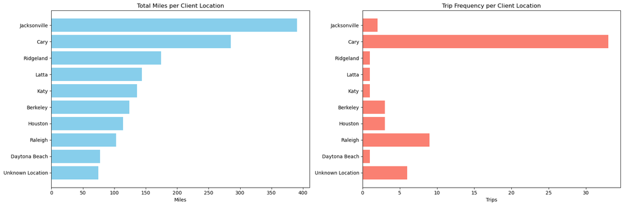

```python
# Filter and aggregate customer visits
client_visits = df[df['PURPOSE'] == 'Customer Visit']
visit_analysis = client_visits.groupby('STOP').agg(
    TOTAL_MILES=('MILES', 'sum'),
    TRIP_COUNT=('MILES', 'count')
).reset_index().sort_values('TOTAL_MILES', ascending=False).head(10)

# Plotting
fig, (ax1, ax2) = plt.subplots(1, 2, figsize=(18, 6))

# Total Miles per Client Location
ax1.barh(visit_analysis['STOP'], visit_analysis['TOTAL_MILES'], color='skyblue')
ax1.set_title('Total Miles per Client Location')
ax1.set_xlabel('Miles')
ax1.invert_yaxis()

# Trip Count per Client Location
ax2.barh(visit_analysis['STOP'], visit_analysis['TRIP_COUNT'], color='salmon')
ax2.set_title('Trip Frequency per Client Location')
ax2.set_xlabel('Trips')
ax2.invert_yaxis()

plt.tight_layout()
plt.savefig("Trip Frequency per Client Location.png")
plt.show()
```